# Analyses: Swabian Aurignacian

Chris Bentz

24.10.2025

# Description

This file enables analyses of feature values for sequences on Swabian Aurgnacian objects (entropy rate, TTR, repetition rate, unigram entropy) as a function of meta information (object type, volume, cave site, etc.).

# Session Info

Give the session info (reduced).

```
## [1] "R version 4.3.3 (2024-02-29)"
```

```
## [1] "x86_64-pc-linux-gnu"
```

# Load libraries

If the libraries are not installed yet, you need to install them using, for example, the command: install.packages(“ggplot2”).

```r
library(ggplot2)
library(ggrepel)
library(ggExtra)
library(gridExtra)
library(ggpubr)
library(ggridges)
library(tidyverse)
library(performance)
library(see)
library(GGally)
library(MASS)
library(forcats)
library(jtools) # for effect plots by predictor variable
library(effectsize)
```

Give the package versions.

```
##   effectsize       jtools         MASS       GGally          see  performance
##      "1.0.0"      "2.3.0" "7.3-60.0.1"      "2.2.1"     "0.10.0"     "0.13.0"
##    lubridate      forcats      stringr        dplyr        purrr        readr
##      "1.9.4"      "1.0.0"      "1.5.1"      "1.1.4"      "1.0.4"      "2.1.5"
##        tidyr       tibble    tidyverse     ggridges       ggpubr    gridExtra
##      "1.3.1"      "3.2.1"      "2.0.0"      "0.5.6"      "0.6.0"        "2.3"
##      ggExtra      ggrepel      ggplot2
##     "0.10.1"      "0.9.6"      "3.5.1"
```

# Load Data

Load feature estimations with meta data for the Aurignacian mobile objects.

```r
sign.data <- read.csv("~/Github/PaleoSigns/results/features/signBase_features.csv")
# select Aurignacian data
#sign.data <- sign.data[sign.data$archaeological_unit == "Aurignacian", ]
```

# Simple Stats

```r
# number of sequences/objects
nrow(sign.data)
```

```
## [1] 213
```

```r
# number of sign tokens
sum(sign.data$num.tokens)
```

```
## [1] 3021
```

```r
# cave sites
table(sign.data$site_name)
```

```
##
##    Bockstein-Törle   Geissenklösterle         Hohle Fels Hohlenstein-Stadel
##                  1                 29                 33                  2
##          Vogelherd
##                148
```

```r
# material
table(sign.data$material)
```

```
##
##    antler      bone    fossil     ivory sandstone     slate     tooth
##         6        68         1       135         1         1         1
```

```r
# object_type
table(sign.data$object_type)
```

```
##
##          antler object                    awl               figurine
##                      3                      4                      6
## figurine anthropomorph      figurine zoomorph                  flute
##                      6                     21                      8
##       perforated baton      personal ornament                 plaque
##                      4                     16                      1
##      possible figurine         possible flute              rod/baton
##                     20                     15                     15
##        spatula/lissoir                   tube             tube/flute
##                     10                      1                     21
##           undetermined
##                     62
```

# Preprocessing

Add columns for object volume and dates.

```r
# volume in cm^3 (mm multiplications divided by 1000)
sign.data$volume <- (sign.data$length_mm*sign.data$width_mm*sign.data$depth)/1000
sign.data$date <- as.numeric(substr(sign.data$date_bp_max, 1, 5))
```

# Collapse Factors

Collapse some factors of meta information which are uncommon and/or related. Note that using the factor levels as is will lead to problems with model fitting, since there are sometimes very few data points per level.

```r
# material: collapse manually
sign.data$material <- fct_collapse(sign.data$material,
             ivory = "ivory",
             antler = "antler",
             bone = "bone",
             other_level = "other")

# object_type: collapse manually
sign.data$object_type <- fct_collapse(sign.data$object_type,
             figurine_anthropomorph = c("figurine anthropomorph",
                          "plaque"),
             # note: the "plaque" is the so-called Adorant with an anthropomorph figure on it.
             figurine_zoomorph = c("figurine zoomorph"),
             tool = c("awl", "perforated baton",
                      "rod/baton", "spatula/lissoir"),
             tube_flute = c("flute", "tube", "tube/flute"),
             personal_ornament = c("personal ornament"),
             other_level = "other")
```

Exclude certain levels of columns to check the robustness of results.

```r
#sign.data <- sign.data[sign.data$object_type != "other" &
#                       sign.data$material != "other" , ]
#sign.data <- sign.data[sign.data$coding_certainty != "uncertain", ]
# sign.data <- sign.data[sign.data$num.tokens < 100, ]

# number of sequences/objects after preprocessing
nrow(sign.data)
```

```
## [1] 213
```

# Simple Statistics Plots

```r
# barplot for object counts per cave site
site.barplot <- ggplot(sign.data, aes(x = site_name, fill = site_name)) +
  geom_bar() +
  ylim(0, 200) +
  geom_text(aes(label = after_stat(count)), stat = "count", vjust = -2.5, hjust = 0.5) +
  geom_text(aes(label = paste(round(after_stat(prop)*100, 1), "%")),
            stat = "prop", vjust = -1, hjust = 0.5) +
  theme(legend.position = "none") +
  theme(axis.text.x = element_text(angle = 45, vjust = 1, hjust=1)) +
  xlab("Cave Site")
  #coord_flip()
#site.barplot

# barplot for object counts per material
material.barplot <- ggplot(sign.data, aes(x = material, fill = material)) +
  geom_bar() +
  ylim(0, 200) +
  geom_text(aes(label = after_stat(count)), stat = "count", vjust = -2.5, hjust = 0.5) +
  geom_text(aes(label = paste(round(after_stat(prop)*100, 1), "%")),
            stat = "prop", vjust = -1, hjust = 0.5) +
  theme(legend.position = "none") +
  theme(axis.text.x = element_text(angle = 45, vjust = 1, hjust=1)) +
  xlab("Material")
  #coord_flip()
#material.barplot

# barplot for object counts per object_type
type.barplot <- ggplot(sign.data, aes(x = object_type, fill = object_type)) +
  geom_bar() +
  ylim(0, 200) +
  geom_text(aes(label = after_stat(count)), stat = "count", vjust = -2.5, hjust = 0.5) +
  geom_text(aes(label = paste(round(after_stat(prop)*100, 1), "%")),
            stat = "prop", vjust = -1, hjust = 0.5) +
  theme(legend.position = "none") +
  theme(axis.text.x = element_text(angle = 45, vjust = 1, hjust=1)) +
  xlab("Object-Type (Carrier)")
  #coord_flip()
#type.barplot
```

## Figures Combined

Combine figures.

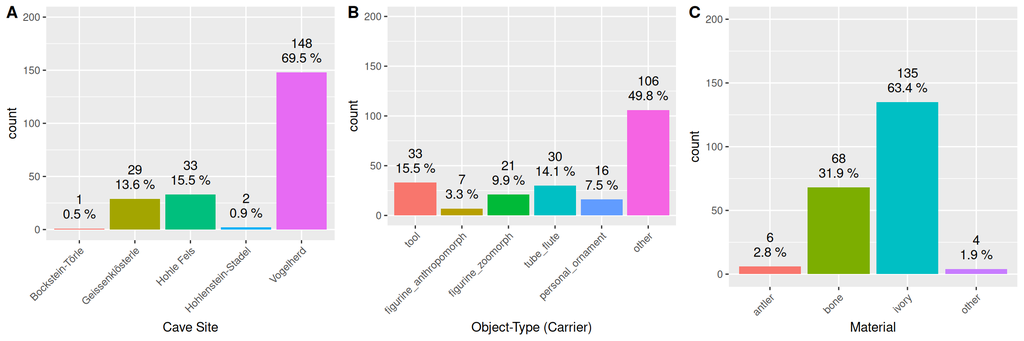

```r
combined.barplot <- ggarrange(site.barplot, type.barplot, material.barplot,
                           ncol = 3, nrow = 1,
                           labels = "AUTO")
combined.barplot
```

Safe complete figure to file.

```r
ggsave("~/Github/PaleoSigns/figures/barPlots_Aurignacian.pdf",
       combined.barplot, dpi = 300, width = 12, height = 4, device = cairo_pdf)
```

# Sign Stats

## Cave Sites

Get frequency counts for individual sign types per cave site.

```r
# initialize dataframe to append results to
caveSigns.df <- data.frame(signs = character(0),
                             Freq = numeric(0),
                             site_name = character(0))

for (site_name in unique(sign.data$site_name)){
  # get all cleaned codings per cave
  codings <- sign.data[sign.data$site_name == site_name, ]$coding_clean
  # collapse to one sequence
  codings.collapsed <- paste(codings, collapse = "")
  # remove underscores
  codings.collapsed <- gsub("_", "", codings.collapsed)
  # split into individual signs
  signs <- unlist(strsplit(codings.collapsed, ""))
  # get data frame with frequency counts
  signs.df <- as.data.frame(table(signs))
  # order by frequency
  signs.df <- signs.df[order(-signs.df$Freq), ]
  # add column with site_name
  signs.df$site_name <- rep(site_name, nrow(signs.df))
  # append results to dataframe
  caveSigns.df <- rbind(caveSigns.df, signs.df)
}
```

Barplot for frequency counts per sign type and cave site.

```r
caveSigns.barplot <- ggplot(caveSigns.df, aes(x = reorder(signs, Freq),
                                          y = Freq, fill = signs)) +
  #ylim(0, 700) +
  geom_text(aes(label = signs), hjust = -1) +
  geom_bar(stat = "identity") +
  facet_wrap(~site_name, ncol = 5) +
  theme(legend.position = "none") +
  coord_flip() +
  xlab("Sign Types") +
  ylab("Token Frequency")
#caveSigns.barplot
```

## Object Type

Get frequency counts for individual sign types per object type.

```r
# initialize dataframe to append results to
objectSigns.df <- data.frame(signs = character(0),
                             Freq = numeric(0),
                             object_type = character(0))

for (object_type in unique(sign.data$object_type)){
  # get all cleaned codings per object type
  codings <- sign.data[sign.data$object_type == object_type, ]$coding_clean
  # collapse to one sequence
  codings.collapsed <- paste(codings, collapse = "")
  # remove underscores
  codings.collapsed <- gsub("_", "", codings.collapsed)
  # split into individual signs
  signs <- unlist(strsplit(codings.collapsed, ""))
  # get data frame with frequency counts
  signs.df <- as.data.frame(table(signs))
  # order by frequency
  signs.df <- signs.df[order(-signs.df$Freq), ]
  # add column with site_name
  signs.df$object_type <- rep(object_type, nrow(signs.df))
  # append results to dataframe
  objectSigns.df <- rbind(objectSigns.df, signs.df)
}
```

```r
objectSigns.barplot <- ggplot(objectSigns.df, aes(x = reorder(signs, Freq),
                                          y = Freq, fill = signs)) +
  #ylim(0, 500) +
  geom_text(aes(label = signs), hjust = -1) +
  geom_bar(stat = "identity") +
  facet_wrap(~object_type, ncol = 6) +
  theme(legend.position = "none") +
  coord_flip() +
  xlab("Sign Types") +
  ylab("Token Frequency")
#objectSigns.barplot
```

## Material

Get frequency counts for individual sign types per material.

```r
# initialize dataframe to append results to
materialSigns.df <- data.frame(signs = character(0),
                             Freq = numeric(0),
                             material = character(0))

for (material in unique(sign.data$material)){
  # get all cleaned codings per cave
  codings <- sign.data[sign.data$material == material, ]$coding_clean
  # collapse to one sequence
  codings.collapsed <- paste(codings, collapse = "")
  # remove underscores
  codings.collapsed <- gsub("_", "", codings.collapsed)
  # split into individual signs
  signs <- unlist(strsplit(codings.collapsed, ""))
  # get data frame with frequency counts
  signs.df <- as.data.frame(table(signs))
  # order by frequency
  signs.df <- signs.df[order(-signs.df$Freq), ]
  # add column with site_name
  signs.df$material <- rep(material, nrow(signs.df))
  # append results to dataframe
  materialSigns.df <- rbind(materialSigns.df, signs.df)
}
```

```r
materialSigns.barplot <- ggplot(materialSigns.df, aes(x = reorder(signs, Freq),
                                          y = Freq, fill = signs)) +
  #ylim(0, 700) +
  geom_text(aes(label = signs), hjust = -1) +
  geom_bar(stat = "identity") +
  facet_wrap(~ material, ncol = 4) +
  theme(legend.position = "none") +
  coord_flip() +
  xlab("Sign Types") +
  ylab("Token Frequency")
#materialSigns.barplot
```

## Figures Combined

Combine figures.

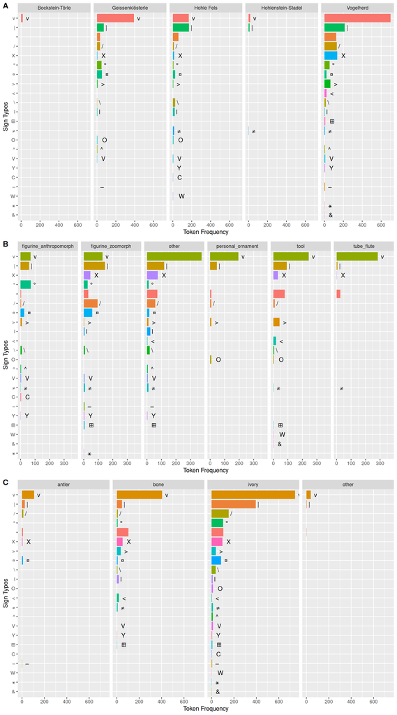

```r
signsCombined.barplot <- ggarrange(caveSigns.barplot, objectSigns.barplot, materialSigns.barplot,
                           nrow = 3,
                           labels = "AUTO")
signsCombined.barplot
```

Safe complete figure to file.

```r
ggsave("~/Github/PaleoSigns/figures/signsCombinedPlot_Aurignacian.pdf",
       signsCombined.barplot, dpi = 300, width = 10, height = 14, device = cairo_pdf)
```

## Select Statistical Feature

```r
# select the statistical feature for further analyses
feature.name <- "hrate.chars"
feature.values <- get(feature.name, sign.data)
```

### Object Type (Carrier)

```r
# create plot
objectType.plot <- ggplot(sign.data, aes(x = feature.values,
                                            y = fct_reorder(object_type, feature.values),
                                            fill = after_stat(x))) +
  geom_density_ridges_gradient(scale = 1, color = "white",
                               quantile_lines = T, quantiles = 2) +
  scale_fill_viridis_c(name = feature.name, option = "D") +
  geom_point(shape = 124, alpha = 0.7, size = 3) +
  xlab(paste("Feature Values ", "(", feature.name, ")", sep = "")) +
  ylab("Object-Type (Carrier)") +
  theme(legend.position = "none")
#objectType.plot
```

### Material

```r
# create plot
material.plot <- ggplot(sign.data, aes(x = feature.values,
                                            y = fct_reorder(material, feature.values),
                                            fill = after_stat(x))) +
  geom_density_ridges_gradient(scale = 1, color = "white",
                               quantile_lines = T, quantiles = 2) +
  scale_fill_viridis_c(name = feature.name, option = "D") +
  geom_point(shape = 124, alpha = 0.7, size = 3) +
  xlab(paste("Feature Values ", "(", feature.name, ")", sep = "")) +
  ylab("Material") +
  theme(legend.position = "none")
#material.plot
```

### Cave Site

```r
# create plot
site.plot <- ggplot(sign.data, aes(x = feature.values,
                                            y = fct_reorder(site_name, feature.values),
                                            fill = after_stat(x))) +
  geom_density_ridges_gradient(scale = 1, color = "white",
                               quantile_lines = T, quantiles = 2) +
  scale_fill_viridis_c(name = feature.name, option = "D") +
  geom_point(shape = 124, alpha = 0.7, size = 3) +
  xlab(paste("Feature Values ", "(", feature.name, ")", sep = "")) +
  ylab("Cave Site") +
  theme(legend.position = "none")
#site.plot
```

### Preservation

```r
# create plot
preservation.plot <- ggplot(sign.data, aes(x = feature.values,
                                            y = fct_reorder(preservation, feature.values),
                                            fill = after_stat(x))) +
  geom_density_ridges_gradient(scale = 1, color = "white",
                               quantile_lines = T, quantiles = 2) +
  scale_fill_viridis_c(name = feature.name, option = "D") +
  geom_point(shape = 124, alpha = 0.7, size = 3) +
  xlab(paste("Feature Values ", "(", feature.name, ")", sep = "")) +
  ylab("Preservation") +
  theme(legend.position = "none")
#preservation.plot
```

### Volume of Object

```r
# create plot
volume.plot <- ggplot(sign.data, aes(x = volume, y = feature.values,
                                     size = volume, color = volume)) +
  geom_point(alpha = 0.5) +
  #geom_text_repel(aes(label = object_type), nudge_x = 0.2) +
  geom_smooth(method = "lm") +
  geom_smooth(method = "loess", linetype = "dashed") +
  xlab(paste("Feature Values ", "(", feature.name, ")", sep = "")) +
  ylab("Volume (cm^3)") +
  theme(legend.position = "none")
#volume.plot
```

### Date

```r
# create plot
date.plot <- ggplot(sign.data, aes(x = date, y = feature.values,
                                   size = volume, color = volume)) +
  geom_point(alpha = 0.5) +
  scale_x_continuous(trans = "reverse") +
  #geom_label_repel(aes(label = object_type)) +
  geom_smooth(method = "lm") +
  #geom_smooth(method = "loess", linetype = "dashed") +
  ylab(paste("Feature Values ", "(", feature.name, ")", sep = "")) +
  xlab("Date (BP, max)") +
  theme(legend.position = "none")
#date.plot
```

### Number of Sign Tokens

```r
# create plot
token.plot <- ggplot(sign.data, aes(x = num.tokens, y = feature.values,
                                   size = volume, color = volume)) +
  geom_point(alpha = 0.5) +
  #geom_label_repel(aes(label = object_type)) +
  geom_smooth(method = "lm") +
  geom_smooth(method = "loess", linetype = "dashed") +
  ylab(paste("Feature Values ", "(", feature.name, ")", sep = "")) +
  xlab("Number of Sign Tokens") +
  theme(legend.position = "none")
#token.plot
```

### Number of Sign Types

```r
# create plot
type.plot <- ggplot(sign.data, aes(x = num.types, y = feature.values,
                                   size = volume, color = volume)) +
  geom_point(alpha = 0.5) +
  #geom_label_repel(aes(label = object_type)) +
  geom_smooth(method = "lm") +
  geom_smooth(method = "loess", linetype = "dashed") +
  ylab(paste("Feature Values ", "(", feature.name, ")", sep = "")) +
  xlab("Number of Sign Types") +
  theme(legend.position = "none")
#type.plot
```

## Figures Combined

Combine figures.

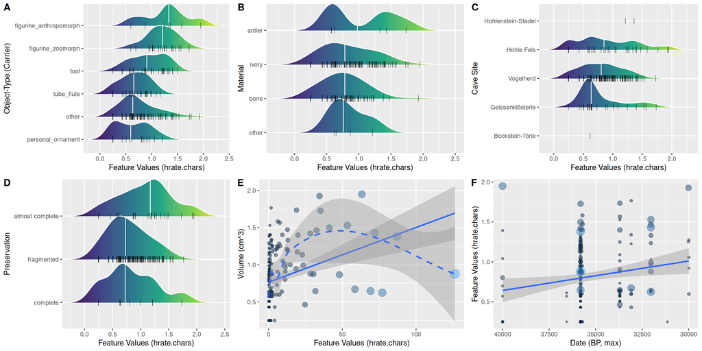

```r
predictor.plot <- ggarrange(objectType.plot, material.plot, site.plot,
                           preservation.plot, volume.plot, date.plot,
                           ncol = 3, nrow = 2,
                           labels = "AUTO")
predictor.plot
```

Safe figure to file.

```r
ggsave("~/Github/PaleoSigns/figures/predictorPlot_Aurignacian.pdf",
       predictor.plot, dpi = 300, width = 14, height = 7, device = cairo_pdf)
```

# Linear Models

We here fit linear models with feature values (e.g. entropy rates) as response variable, and meta information (e.g. volume, type of object, material etc.) as predictor variables. Alternatively, especially the number of different sign types could also be used as a response, as this is highly correlated with the entropy rate. However, model checking reveals that some of the assumptions of linear regression (e.g. normality of residuals) are not met in this case. Some of the predictors are numerical (e.g. volume) while others are categorical (e.g. material, object_type). Arguably, a linear multiple regression model is appropriate since each object and its respective sequence of signs can be seen as an independent data point. Of course, it is theoretically possible that the same paleolithic person has produced a subset of the objects. However, there is no way of knowing this with certainty. Hence, there is no clear evidence for “repeated measures” as in controlled experiments with humans (with subjects and items, cf. Baayen, 2013) – which would require a mixed-effects structure.

We here fit models stepwise by adding predictors one at a time on top of a baseline model (intercept only). We follow the advice by Baayen (2013) to use AIC as a criterion for model selection. If AIC decreases when a predictor is added, we leave the predictor in the model. We also consider interactions between object type and date as well as volume. It is theoretically conceivable that for cultures of the early Aurignacien (c. 40 000 years ago) object types might have been associated with information density (entropy rates) in a different way than for later Aurignacien cultures (c. 30 000 years ago). Similarly, volumes of objects might have played different roles in earlier compared to later periods.

## Baseline Model

```r
# model code
baseline.model <- lm(feature.values ~ 1, sign.data)
# model specification
formula.baseline <- "intercept"
# model summary
baseline.summary <- summary(baseline.model)
# get model information from summary
df.baseline <- baseline.summary$df[1]
res.df.baseline <- baseline.summary$df[2]
f.statistic.baseline <- NA
p.value.baseline <- NA
aic.baseline <- AIC(baseline.model)
```

## Models with predictors added sequentially

### Volume

```r
# model code
model1 <- lm(feature.values ~ volume, sign.data)
model1.summary <- summary(model1)
formula.model1 <- "intercept + volume"
# get model information
df.model1 <- model1.summary$df[1]
res.df.model1 <- model1.summary$df[2]
f.statistic.model1 <- model1.summary$fstatistic[[1]]
p.value.model1 <- unname(pf(model1.summary$fstatistic[1L],
                            model1.summary$fstatistic[2L],
                            model1.summary$fstatistic[3L],
                            lower.tail = FALSE))
aic.model1 <- AIC(model1)
```

### Volume + Date (age)

```r
# model code
model2 <- lm(feature.values ~ volume + date, sign.data)
model2.summary <- summary(model2)
formula.model2 <- "intercept + volume + date"
# get model information
df.model2 <- model2.summary$df[1]
res.df.model2 <- model2.summary$df[2]
f.statistic.model2 <- model2.summary$fstatistic[[1]]
p.value.model2 <- unname(pf(model2.summary$fstatistic[1L],
                            model2.summary$fstatistic[2L],
                            model2.summary$fstatistic[3L],
                            lower.tail = FALSE))
aic.model2 <- AIC(model2)
```

### Volume + Date (age) + Object type

```r
model3 <- lm(feature.values ~ volume + date + object_type, sign.data)
model3.summary <- summary(model3)
formula.model3 <- "intercept + volume + date + object_type"
# get model information
df.model3 <- model3.summary$df[1]
res.df.model3 <- model3.summary$df[2]
f.statistic.model3 <- model3.summary$fstatistic[[1]]
p.value.model3 <- unname(pf(model3.summary$fstatistic[1L],
                            model3.summary$fstatistic[2L],
                            model3.summary$fstatistic[3L],
                            lower.tail = FALSE))
aic.model3 <- AIC(model3)
```

### Volume + Date (age) + Object type + Cave Site

```r
model4 <- lm(feature.values ~ volume + date + object_type + site_name, sign.data)
formula.model4 <- "intercept + volume + date + object_type + site_name"
model4.summary <- summary(model4)
# get model information
df.model4 <- model4.summary$df[1]
res.df.model4 <- model4.summary$df[2]
f.statistic.model4 <- model4.summary$fstatistic[[1]]
p.value.model4 <- unname(pf(model4.summary$fstatistic[1L],
                            model4.summary$fstatistic[2L],
                            model4.summary$fstatistic[3L],
                            lower.tail = FALSE))
aic.model4 <- AIC(model4)
```

### Volume + Date (age) + Object type + Preservation

```r
model5 <- lm(feature.values ~ volume + date + object_type + preservation, sign.data)
formula.model5 <- "intercept + volume + date + object_type + preservation"
model5.summary <- summary(model5)
# get model information
df.model5 <- model5.summary$df[1]
res.df.model5 <- model5.summary$df[2]
f.statistic.model5 <- model5.summary$fstatistic[[1]]
p.value.model5 <- unname(pf(model5.summary$fstatistic[1L],
                            model5.summary$fstatistic[2L],
                            model5.summary$fstatistic[3L],
                            lower.tail = FALSE))
aic.model5 <- AIC(model5)
```

### Volume + Date (age) + Object type + Material

```r
model6 <- lm(feature.values ~ volume + date + object_type + material, sign.data)
formula.model6 <- "intercept + volume + date + object_type + material"
model6.summary <- summary(model6)
# get model information
df.model6 <- model6.summary$df[1]
res.df.model6 <- model6.summary$df[2]
f.statistic.model6 <- model6.summary$fstatistic[[1]]
p.value.model6 <- unname(pf(model6.summary$fstatistic[1L],
                            model6.summary$fstatistic[2L],
                            model6.summary$fstatistic[3L],
                            lower.tail = FALSE))
aic.model6 <- AIC(model6)
```

### Volume*Preservation + Date (age) + Object type

```r
model7 <- lm(feature.values ~ volume*preservation + date + object_type, sign.data)
formula.model7 <- "intercept + volume*preservation + date + object_type"
model7.summary <- summary(model7)
# get model information
df.model7 <- model7.summary$df[1]
res.df.model7 <- model7.summary$df[2]
f.statistic.model7 <- model7.summary$fstatistic[[1]]
p.value.model7 <- unname(pf(model7.summary$fstatistic[1L],
                            model7.summary$fstatistic[2L],
                            model7.summary$fstatistic[3L],
                            lower.tail = FALSE))
aic.model7 <- AIC(model7)
```

### Volume*Object type + Date (age)

```r
model8 <- lm(feature.values ~ volume*object_type + date, sign.data)
formula.model8 <- "intercept + volume*object_type + date"
model8.summary <- summary(model8)
# get model information
df.model8 <- model8.summary$df[1]
res.df.model8 <- model8.summary$df[2]
f.statistic.model8 <- model8.summary$fstatistic[[1]]
p.value.model8 <- unname(pf(model8.summary$fstatistic[1L],
                            model8.summary$fstatistic[2L],
                            model8.summary$fstatistic[3L],
                            lower.tail = FALSE))
aic.model8 <- AIC(model8)
```

### Volume + Date (age)*Object type

```r
model9 <- lm(feature.values ~ volume + date*object_type, sign.data)
formula.model9 <- "intercept + volume + date*object_type"
model9.summary <- summary(model9)
# get model information
df.model9 <- model9.summary$df[1]
res.df.model9 <- model9.summary$df[2]
f.statistic.model9 <- model9.summary$fstatistic[[1]]
p.value.model9 <- unname(pf(model9.summary$fstatistic[1L],
                            model9.summary$fstatistic[2L],
                            model9.summary$fstatistic[3L],
                            lower.tail = FALSE))
aic.model9 <- AIC(model9)
```

Combine results in a table

```r
# conatenate results per model
model.formula <- c(formula.baseline, formula.model1, formula.model2,
                   formula.model3, formula.model4, formula.model5,
                   formula.model6, formula.model7, formula.model8,
                   formula.model9)
df <- c(df.baseline, df.model1, df.model2, df.model3, df.model4, df.model5,
        df.model6, df.model7, df.model8, df.model9)
res.df <- c(res.df.baseline, res.df.model1, res.df.model2, res.df.model3,
            res.df.model4, res.df.model5, res.df.model6, res.df.model7,
            res.df.model8, res.df.model9)
f.statistic <- c(f.statistic.baseline, f.statistic.model1, f.statistic.model2,
                 f.statistic.model3, f.statistic.model4, f.statistic.model5,
                 f.statistic.model6, f.statistic.model7, f.statistic.model8,
                 f.statistic.model9)
p.value <- c(p.value.baseline, p.value.model1, p.value.model2, p.value.model3,
             p.value.model4, p.value.model5, p.value.model6, p.value.model7,
             p.value.model8, p.value.model9)
aic <- c(aic.baseline, aic.model1, aic.model2, aic.model3, aic.model4,
         aic.model5, aic.model6, aic.model7, aic.model8, aic.model9)

# create data frame
model.results <- data.frame(model.formula, df, res.df, f.statistic, p.value, aic)
print(model.results)
```

```
##                                             model.formula df res.df f.statistic
## 1                                               intercept  1    212          NA
## 2                                      intercept + volume  2    207   23.231056
## 3                               intercept + volume + date  3    203   13.645731
## 4                 intercept + volume + date + object_type  8    198    9.859579
## 5     intercept + volume + date + object_type + site_name 10    196    7.954553
## 6  intercept + volume + date + object_type + preservation 10    196    8.452801
## 7      intercept + volume + date + object_type + material 11    195    7.235423
## 8    intercept + volume*preservation + date + object_type 12    194    7.072083
## 9                   intercept + volume*object_type + date 13    193    6.486836
## 10                  intercept + volume + date*object_type 13    193    6.348522
##         p.value      aic
## 1            NA 198.1068
## 2  2.776934e-06 174.9456
## 3  2.751993e-06 171.0795
## 4  1.553763e-10 145.4609
## 5  5.317065e-10 146.9272
## 6  1.210243e-10 143.5037
## 7  1.084769e-09 148.0558
## 8  4.766233e-10 145.6047
## 9  1.144602e-09 147.2621
## 10 1.923593e-09 148.5284
```

Export data frame with results of linear models.

```r
write.csv(model.results, file = "~/Github/PaleoSigns/tables/lmResults.csv", row.names = F)
```

Manually select best model for further usage. Note that a decrease in AIC (compared to previous best model) is here considered as criterion for leaving the respective predictor variable in the model.

```r
best.model <- model5
```

## Model Summary

```r
summary(best.model)
```

```
##
## Call:
## lm(formula = feature.values ~ volume + date + object_type + preservation,
##     data = sign.data)
##
## Residuals:
##      Min       1Q   Median       3Q      Max
## -0.74618 -0.23328 -0.05947  0.22983  0.99987
##
## Coefficients:
##                                     Estimate Std. Error t value Pr(>|t|)
## (Intercept)                        1.679e+00  4.833e-01   3.475 0.000629 ***
## volume                             2.923e-03  1.668e-03   1.752 0.081266 .
## date                              -1.754e-05  1.347e-05  -1.302 0.194303
## object_typefigurine_anthropomorph  2.889e-01  1.484e-01   1.946 0.053044 .
## object_typefigurine_zoomorph       2.284e-01  9.365e-02   2.439 0.015604 *
## object_typetube_flute             -2.192e-01  8.653e-02  -2.533 0.012092 *
## object_typepersonal_ornament      -3.222e-01  1.171e-01  -2.753 0.006466 **
## object_typeother                  -1.390e-01  6.821e-02  -2.039 0.042835 *
## preservationcomplete              -1.742e-01  1.332e-01  -1.308 0.192515
## preservationfragmented            -1.992e-01  8.414e-02  -2.368 0.018856 *
## ---
## Signif. codes:  0 '***' 0.001 '**' 0.01 '*' 0.05 '.' 0.1 ' ' 1
##
## Residual standard error: 0.3332 on 196 degrees of freedom
##   (7 observations deleted due to missingness)
## Multiple R-squared:  0.2796, Adjusted R-squared:  0.2465
## F-statistic: 8.453 on 9 and 196 DF,  p-value: 1.21e-10
```

## Effect size

Using the effectsize package function r2_semipartial() for getting partial effect sizes ($\Delta R^2$) for each predictor variable in the best model. This metric is tested in Algina et al. (2008) for different sample sizes and number of predictor variables.

```r
r2_semipartial(best.model)
```

```
## Term         |      sr2 |       95% CI
## --------------------------------------
## volume       |     0.01 | [0.00, 1.00]
## date         | 6.23e-03 | [0.00, 1.00]
## object_type  |     0.13 | [0.07, 1.00]
## preservation |     0.02 | [0.00, 1.00]
##
## - One-sided CIs: upper bound fixed at [1.00].
```

Interpretation: Only the object type variable is associated with a $\Delta R^2$ value significantly higher than zero (i.e. the CI does not include zero). An effect size value of $\Delta R^2 = 0.13$ is considered medium (upper range) by Field (2013).

## Checking of Model Assumptions

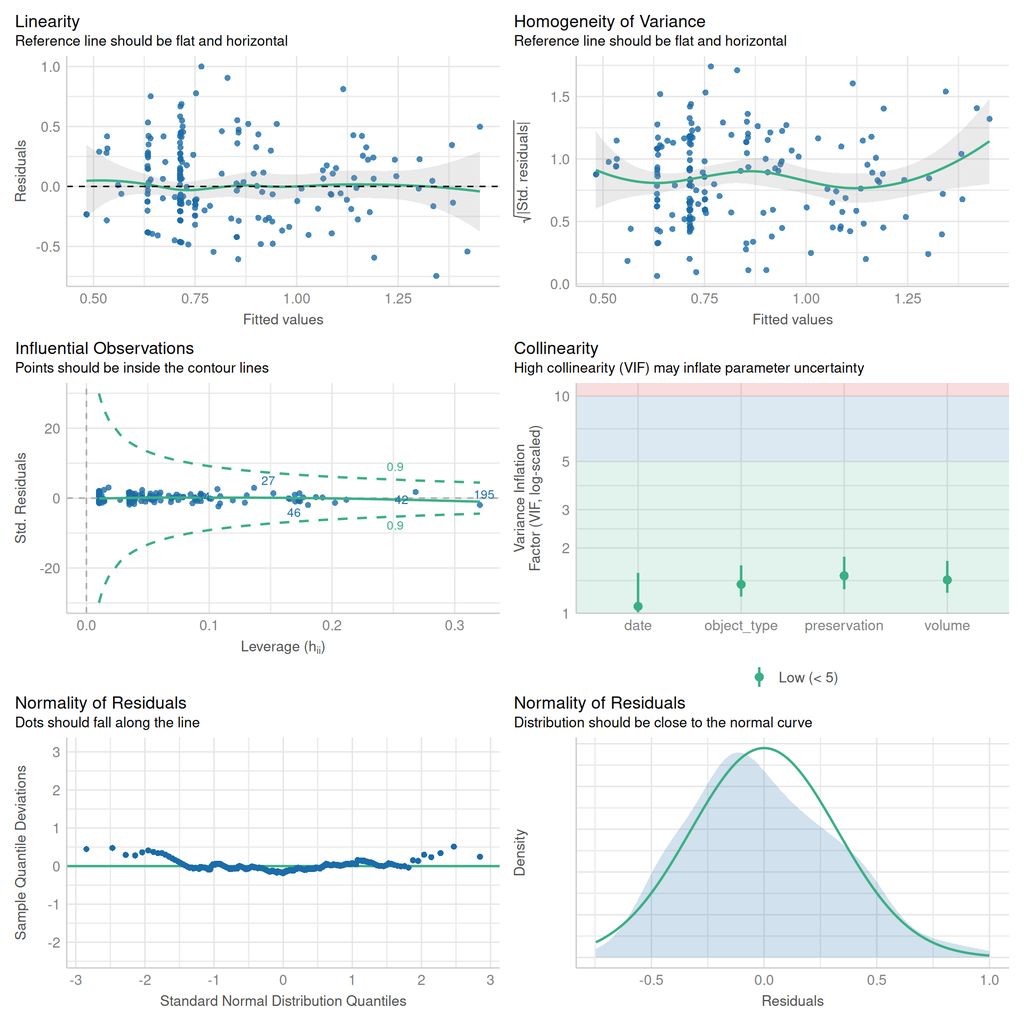

```r
check_model(best.model)
```

Write to file.

```r
png(filename = file.path("~/Github/PaleoSigns/figures/", "modelCheckingPlot.png"),
    width = 10, height = 10, units = "in", res = 300)
check_model(best.model)
dev.off()
```

## Shapiro-Wilk Test for Normality of Residuals

```r
shapiro.test(rstandard(best.model))
```

```
##
##  Shapiro-Wilk normality test
##
## data:  rstandard(best.model)
## W = 0.98394, p-value = 0.01908
```

# Plot Linear Model Coefficients

```r
coefficient.plot <- plot_coefs(best.model,
                               plot.distributions = F,
                               rescale.distributions = F,
           coefs = c("Object type: figurine anthropomorph" = "object_typefigurine_anthropomorph",
                     "Object type: figurine zoomorph" = "object_typefigurine_zoomorph",
                     "Object type: tube or flute" = "object_typetube_flute",
                     "Object type: tool" = "object_typetool",
                     "Object type: personal ornament" = "object_typepersonal_ornament",
                     "Object type: other" = "object_typeother",
                     "Material: antler" = "materialantler",
                     "Material: bone" = "materialbone",
                     "Material: ivory" = "materialivory",
                     "Material: other" = "materialother",
                     "Volume" = "volume",
                     "Date (age of object)" = "date",
                     "Preservation: complete" = "preservationcomplete",
                     "Preservation: fragmented" = "preservationfragmented",
                     "Site name: Hohle Fels" = "site_nameHohle Fels",
                     "Site name: Vogelherd" = "site_nameVogelherd"))
#coefficient.plot
```

### Sequence plot

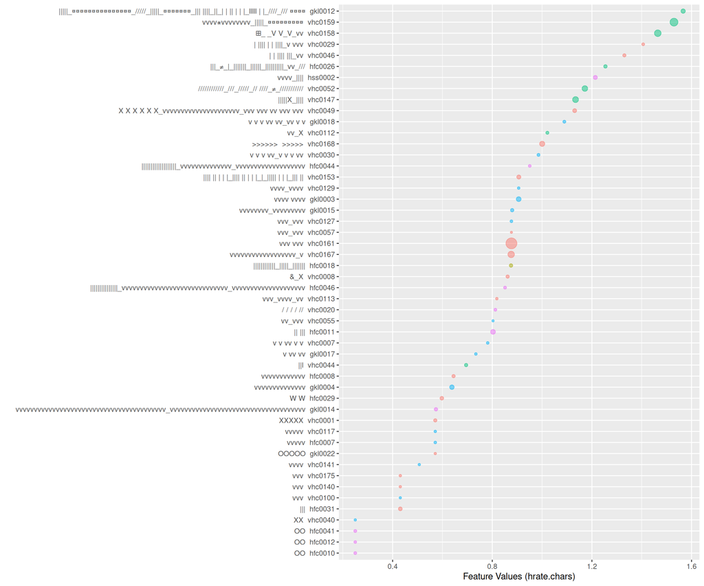

```r
# exclude "other" category (otherwise the sequence plot is overcrowded)
sign.data.modified <- sign.data[sign.data$object_type != "other", ]
# take random subsample as otherwise the sequence plot is overcrowded
set.seed(09012020)
sign.data.subsample <- sample_n(sign.data.modified, 50)
# get feature values for subsample
feature.values.modified <- get(feature.name, sign.data.modified)
feature.values.subsample <- get(feature.name, sign.data.subsample)

# create plot
sequence.plot <- ggplot(sign.data.subsample, aes(x = feature.values.subsample,
                                                y = reorder(paste(coding_clean, object_id, sep = "  "),
                                                            feature.values.subsample, mean),
                                   size = volume, color = object_type)) +
  geom_point(alpha = 0.5) +
  ylab("") +
  xlab(paste("Feature Values ", "(", feature.name, ")", sep = "")) +
  theme(legend.position = "none")
sequence.plot
```

### Density plot

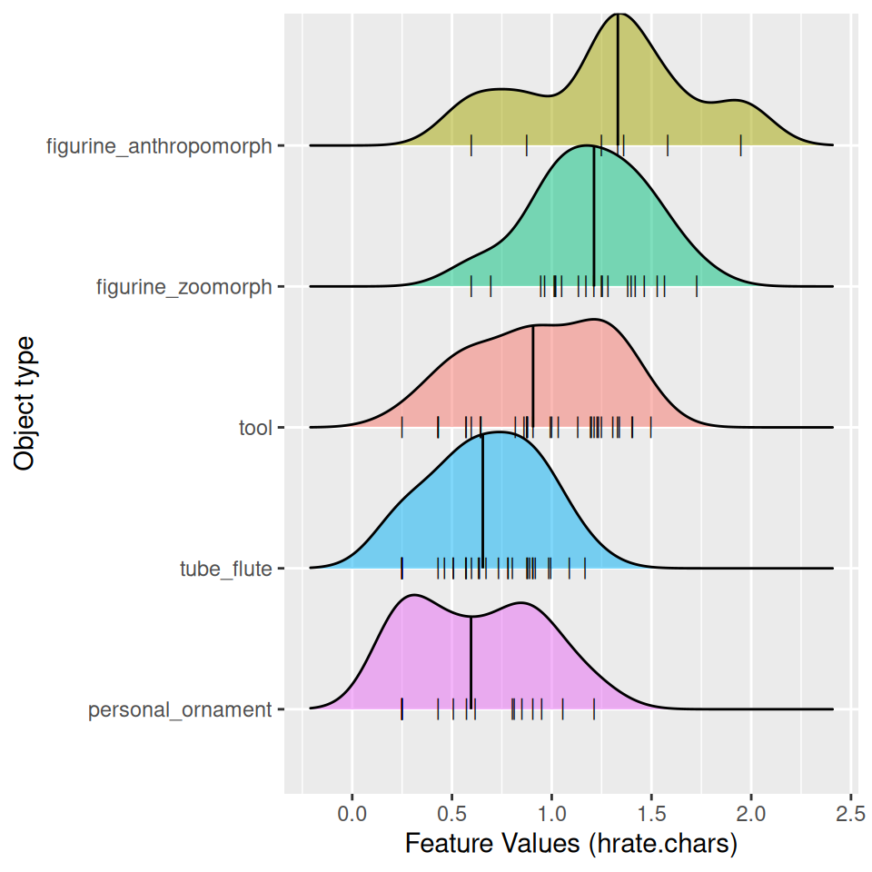

```r
density.plot <- ggplot(sign.data.modified, aes(x = feature.values.modified,
                                               y = fct_reorder(object_type, feature.values.modified),
                      fill = object_type)) +
  geom_density_ridges(alpha = 0.5, scale = 1, quantile_lines = T,
                      quantiles = 2) +
  geom_point(shape = 124, alpha = 0.9, size = 3) +
  ylab("Object type") +
  xlab(paste("Feature Values ", "(", feature.name, ")", sep = "")) +
  theme(legend.position = "none")
density.plot
```

Combine figures.

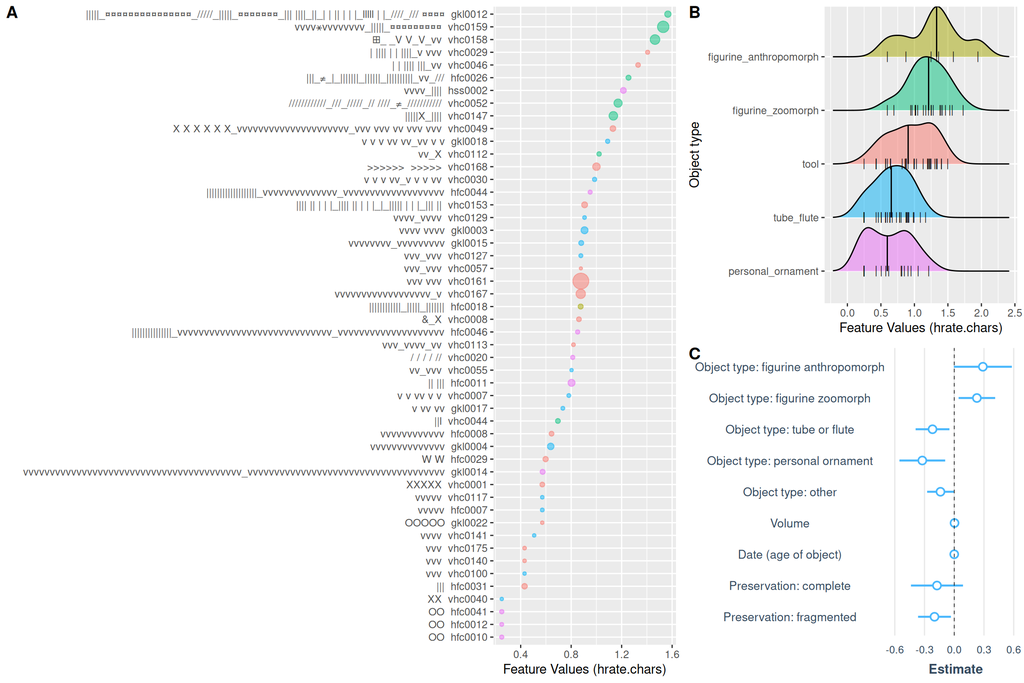

```r
model.plot <- ggarrange(sequence.plot,               # First column with sequence plot
          ggarrange(density.plot, coefficient.plot,
                    ncol = 1, labels = c("B", "C")), # Second column with density and coefficient plot
          ncol = 2,
          labels = "A",
          widths = c(2,1)                            # Relative widths of panels
          )
model.plot
```

Safe figure to file.

```r
ggsave("~/Github/PaleoSigns/figures/modelPlot_Aurignacian.pdf",
       model.plot, dpi = 300, width = 12, height = 8, device = cairo_pdf)
```

# Package References

```
## Wickham H (2016). _ggplot2: Elegant Graphics for Data Analysis_.
## Springer-Verlag New York. ISBN 978-3-319-24277-4,
## <https://ggplot2.tidyverse.org>.
```

```
## Slowikowski K (2024). _ggrepel: Automatically Position Non-Overlapping
## Text Labels with 'ggplot2'_. R package version 0.9.6,
## <https://CRAN.R-project.org/package=ggrepel>.
```

```
## Attali D, Baker C (2023). _ggExtra: Add Marginal Histograms to
## 'ggplot2', and More 'ggplot2' Enhancements_. R package version 0.10.1,
## <https://CRAN.R-project.org/package=ggExtra>.
```

```
## Auguie B (2017). _gridExtra: Miscellaneous Functions for "Grid"
## Graphics_. R package version 2.3,
## <https://CRAN.R-project.org/package=gridExtra>.
```

```
## Kassambara A (2023). _ggpubr: 'ggplot2' Based Publication Ready Plots_.
## R package version 0.6.0, <https://CRAN.R-project.org/package=ggpubr>.
```

```
## Wilke C (2024). _ggridges: Ridgeline Plots in 'ggplot2'_. R package
## version 0.5.6, <https://CRAN.R-project.org/package=ggridges>.
```

```
## Wickham H, Averick M, Bryan J, Chang W, McGowan LD, François R,
## Grolemund G, Hayes A, Henry L, Hester J, Kuhn M, Pedersen TL, Miller E,
## Bache SM, Müller K, Ooms J, Robinson D, Seidel DP, Spinu V, Takahashi
## K, Vaughan D, Wilke C, Woo K, Yutani H (2019). "Welcome to the
## tidyverse." _Journal of Open Source Software_, *4*(43), 1686.
## doi:10.21105/joss.01686 <https://doi.org/10.21105/joss.01686>.
```

```
## Lüdecke D, Ben-Shachar M, Patil I, Waggoner P, Makowski D (2021).
## "performance: An R Package for Assessment, Comparison and Testing of
## Statistical Models." _Journal of Open Source Software_, *6*(60), 3139.
## doi:10.21105/joss.03139 <https://doi.org/10.21105/joss.03139>.
```

```
## Lüdecke D, Patil I, Ben-Shachar M, Wiernik B, Waggoner P, Makowski D
## (2021). "see: An R Package for Visualizing Statistical Models."
## _Journal of Open Source Software_, *6*(64), 3393.
## doi:10.21105/joss.03393 <https://doi.org/10.21105/joss.03393>.
```

```
## Venables WN, Ripley BD (2002). _Modern Applied Statistics with S_,
## Fourth edition. Springer, New York. ISBN 0-387-95457-0,
## <https://www.stats.ox.ac.uk/pub/MASS4/>.
```

[output not shown]

```
## Ben-Shachar MS, Lüdecke D, Makowski D (2020). "effectsize: Estimation
## of Effect Size Indices and Standardized Parameters." _Journal of Open
## Source Software_, *5*(56), 2815. doi:10.21105/joss.02815
## <https://doi.org/10.21105/joss.02815>,
## <https://doi.org/10.21105/joss.02815>.
```

# Literature References

Algina, J., Keselman, H. J., & Penfield, R. D. (2008). Confidence intervals for the squared multiple semipartial correlation coefficient. Journal of Modern Applied Statistical Methods, 7(1), 2.

Baayen, R. H. (2008). Analyzing Linguistic Data. A Practical Introduction to Statistics Using R. Cambridge: Cambridge University Press.

Baayen, H. (2013). Multivariate Statistics. In: Podesva, R. J. & Sharma, D. (eds.), Research methods in linguistics. Cambridge: Cambridge University Press, p. 337-372.

Field, A (2013) Discovering statistics using IBM SPSS Statistics. Fourth Edition. Sage: London.